# **Exploratory Data Analysis**

# **Purpose**

The purpose of the exploratory analysis is to utilize tabular and visual devices to investigate answers to proposed initial questions, to devise more complex follow-up questions, and then explore answers for the follow-up questions. Serious time and attention should be given to the exploratory data analysis since much of the information and results will directly lead to future modeling for statistical inference. This is your group’s opportunity to creatively dive into your data to pick out parts that are relevant and interesting for sharing with the class in presentation and for communicating with the instructor in written paper.

# **Requirements**

In the project proposal, each member of your group should have created 2 initial questions that the Creator should have proposed to the Instructor or Instructional Assistant (IA). For the exploratory data analysis, each member of the group will create 1 table or figure that explore answers to the questions he or she came up with. As a team, you will then come up with 4 follow-up questions that stem from what you learned from your initial investigation. These 4 follow-up questions should be more advanced and specific. For 2 of the 4 follow-up questions, you are required to create a table or figure that explore answers. Finally, your group will have to write a short 2 paragraph summary that summarizes what you discovered in your exploratory data analysis. The first paragraph should summarize what you discovered from your investigation of the initial questions and the second paragraph shoud summarize what you discovered from your investigation of the follow-up questions.

For this part, each member should be responsible for the table or figure that answers each of the 2 questions assigned to them. Meet as a team to discuss your discoveries and develop 4 additional more-interesting questions. As a group determine which tables and/or figures would be a good first start at trying to explore answers for 2 of the 4 follow-up questions. Figure out how you will delegate the responsibility for creation of the tables and or figures and the writing of the 2 paragraph summary. I recommend doing tables or figures for all 4 follow-up questions as a team and then discussing the results to determine which of the 2 are most worthy for discussion in the exploratory data analysis.

The Interpreter should schedule a 5 minute meeting during office hours of either the Instructor or Instructional Assistant (IA). To reserve your 5 minute time slot, email ahead of time. Time slots will be priortized according to email and posted on a google spreadsheet linked on the website. I highly recommend scheduling your meeting as soon as possible to ensure you have a spot before the deadline. If your Interpreter fails to schedule the project proposal meeting before the deadline, a minimum 2 point penalty will be given. Also, if the Interpreter fails to attend the meeting scheduled, a penalty will also be applied. This penalty applies to your entire group.

In the meeting, the Interpreter should effectively provide an overview of what the entire group discovered from investigating the initial questions and from investigating the follow-up questions. The Interpreter should explain to the Instructor or IA the current status of the group project and provide the vision of the group on the finishing of the project. The four follow-up questions should be shared along with any future plans for investigating these follow up questions. The Interpeter should have at least four tables and/or figures that highlight instances of statistical learning about the data. These tables and/or figures should be ready on a laptop to show the instructor or IA.

The Deliverer is responsible for compiling all the information into the RMarkdown template provided on the course website. This document should be carefully proofread and submitted as an HTML file via Canvas by the due date. A minimum 2 point penalty will be given, if this document is submitted late. This penalty applies to your entire group. The tables and figures for the initial questions should be generated using R code chunks. The R code and output should be displayed in the HTML file. The 2 paragraph summary should be written in complete sentences and free of grammatical/spelling errors.

#DATA READING AND CLEANING

```r
steam_games <- read.csv("steam.csv")

steam_games_final = steam_games %>%
  rename(age=required_age) %>%
  mutate(num_platforms = str_count(platforms,";")+1, .after=platforms) %>%
  filter(english==1)
# steam_games_final
```

# **QUESTION 1: Are some genre combinations more expensive than others?**

```r
team_games_genre <- steam_games_final %>%
  select(genres, price) %>%
    group_by(genres) %>%
  summarise(avg_price=mean(price)) %>%
    arrange(desc(avg_price))

head(team_games_genre)
```

```
## # A tibble: 6 × 2
##   genres                                                                 avg_p…¹
##   <chr>                                                                    <dbl>
## 1 Animation & Modeling;Design & Illustration;Education;Software Trainin…   178.
## 2 Animation & Modeling;Design & Illustration;Video Production              155.
## 3 Animation & Modeling;Design & Illustration;Education;Utilities;Web Pu…   115.
## 4 Animation & Modeling;Design & Illustration;Game Development              110.
## 5 Violent;Gore;Action;Adventure;Indie;Massively Multiplayer                 79.9
## 6 Animation & Modeling;Education;Utilities;Web Publishing                   70.0
## # … with abbreviated variable name ¹avg_price
```

```r
#It looks like with Animation and Modeling and Design having the highest average price, some genres are indeed more expensive than the others presumably because of the demand of these genres.
```

# **QUESTION 2: What is the relationship between the price of the product and the median playtime?**

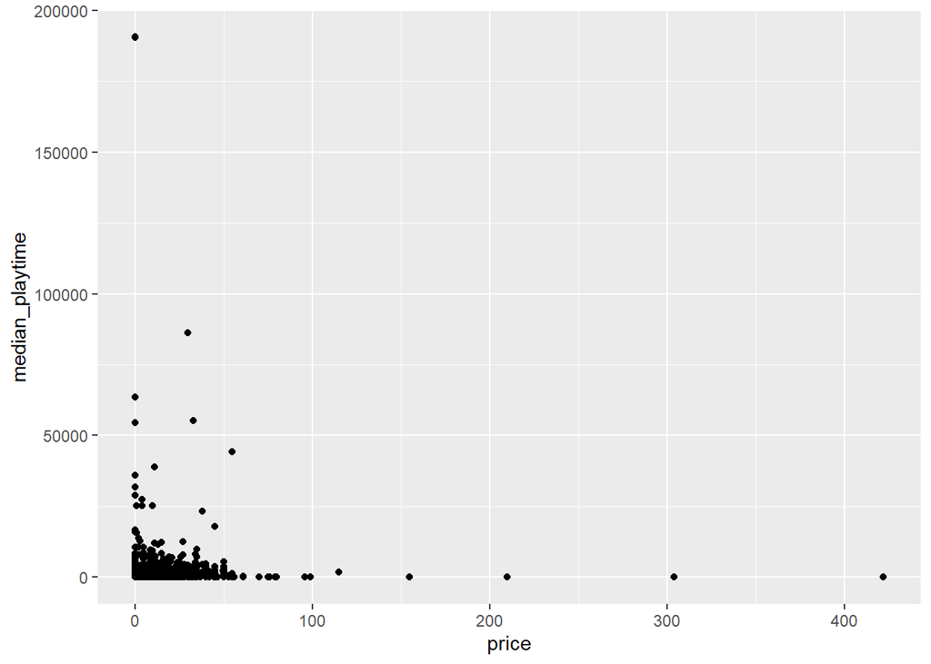

```r
steam_games_price_median_playtime = steam_games_final %>%
  select(price, median_playtime)
ggplot(steam_games_final,aes(x= price, y= median_playtime))+geom_point()
```

```r
#It looks like the median playtime mostly exists under 50000 and is high for prices that are lower than 100. So, cheaper games most likely have a greater median playtime presumably because of the affordability and accessibility.
```

# **QUESTION 3: Which developer has the most negative ratings?**

```r
steam_games_negative <- steam_games_final %>%
  select("developer", "negative_ratings") %>%
  group_by(developer) %>%
  summarise_each(funs(sum)) %>%
  arrange(desc(negative_ratings))
head(steam_games_negative, 5)
```

```
## # A tibble: 5 × 2
##   developer                       negative_ratings
##   <chr>                                      <int>
## 1 PUBG Corporation                          487076
## 2 Valve;Hidden Path Entertainment           402313
## 3 Valve                                     220682
## 4 Rockstar North                            139788
## 5 Bohemia Interactive                       100566
```

# **QUESTION 4: How does the number of in-game achievements correlate with the median playtime?**

```r
achievements <- steam_games_final %>%
  select(categories, achievements, median_playtime) %>%
  group_by(categories) %>%
  summarise_each(funs(sum)) %>%
  arrange(desc(achievements))

achievements
```

```
## # A tibble: 3,321 × 3
##    categories                                                    achie…¹ media…²
##    <chr>                                                           <int>   <int>
##  1 Single-player;Steam Achievements                               591450   67193
##  2 Single-player;Steam Achievements;Steam Trading Cards            53257  189038
##  3 Single-player;Steam Achievements;Steam Cloud                    50489   10923
##  4 Single-player                                                   34702  399889
##  5 Single-player;Steam Achievements;Steam Trading Cards;Steam C…   32394  117701
##  6 Single-player;Steam Achievements;Steam Cloud;Stats;Steam Lea…   28209    2384
##  7 Single-player;Steam Achievements;Partial Controller Support     22743   41729
##  8 Single-player;Steam Achievements;Full controller support;Ste…   18335  128473
##  9 Single-player;Steam Achievements;Steam Trading Cards;Partial…   12475   61714
## 10 Single-player;Steam Achievements;Full controller support;Ste…   12048   45542
## # … with 3,311 more rows, and abbreviated variable names ¹achievements,
## #   ²median_playtime
```

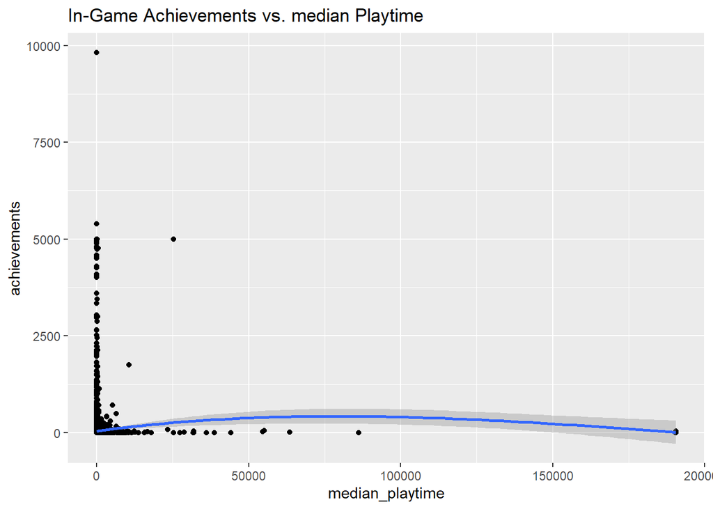

```r
ggplot(steam_games_final,aes(x=median_playtime,y=achievements))+geom_point() + geom_smooth() +
  ggtitle("In-Game Achievements vs. median Playtime")
```

# **QUESTION 5: Is there a relationship between the release date and the number of negative ratings for a game?**

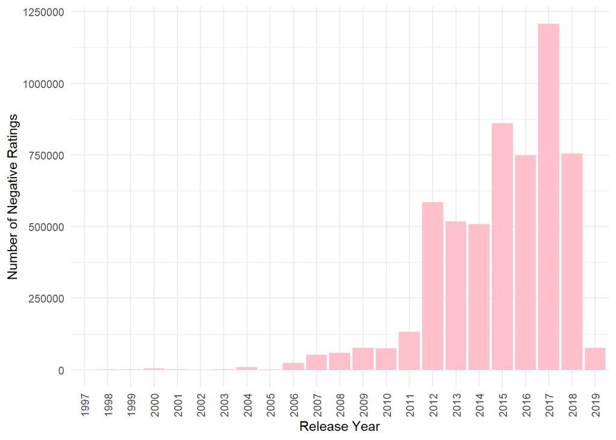

```r
co5 = steam_games_final %>%
  select(release_date,negative_ratings) %>%
  mutate(release_date=str_replace_all(release_date,"-", "")) %>%
  mutate(release_year=substr(release_date,1,4),release_month=substr(release_date,5,6))


co5_graph = co5 %>%
  ggplot(aes(x=release_year,y=negative_ratings)) +
  geom_bar(stat="identity",fill="pink") +
  xlab("Release Year") + ylab("Number of Negative Ratings") +
  theme_minimal() +
  theme(axis.text.x = element_text(angle = 90, vjust = 0.5, hjust=1))

co5_graph
```

# **FOLLOW-UP QUESTION/CODE: How does price/proportion of negative ratings change across month and year?**

```r
#PRICE
price_map = steam_games_final %>%
  select(release_date,negative_ratings,price) %>%
  mutate(release_date=str_replace_all(release_date,"-", "")) %>%
  mutate(release_year=substr(release_date,1,4),release_month=substr(release_date,5,6)) %>%
  group_by(release_year,release_month) %>%
  summarise(mean_price=mean(price))
```

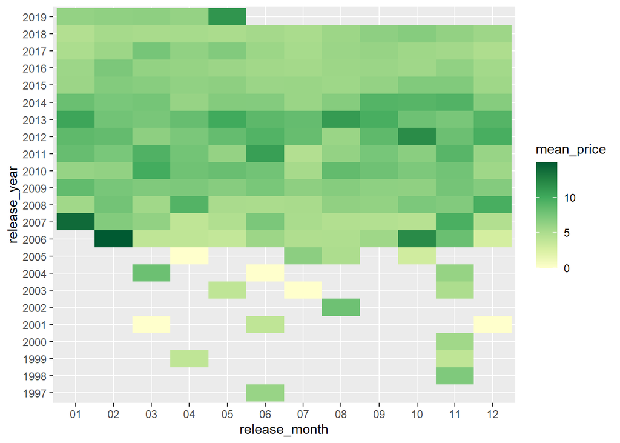

```r
ggplot(price_map,mapping = aes(x=release_month,y=release_year)) + geom_tile(mapping=aes(fill=mean_price)) + scale_fill_distiller(palette = "YlGn", direction=2)
```

```r
#NEGATIVE RATINGS PROPORTIONS
nrating_map = steam_games_final %>%
  select(release_date,negative_ratings,positive_ratings)%>%
  mutate(release_date=str_replace_all(release_date,"-", "")) %>%
  mutate(release_year=substr(release_date,1,4),release_month=substr(release_date,5,6)) %>%
  group_by(release_year,release_month) %>%
  summarise(prop_neg_ratings = mean(negative_ratings/(negative_ratings + positive_ratings)))
```

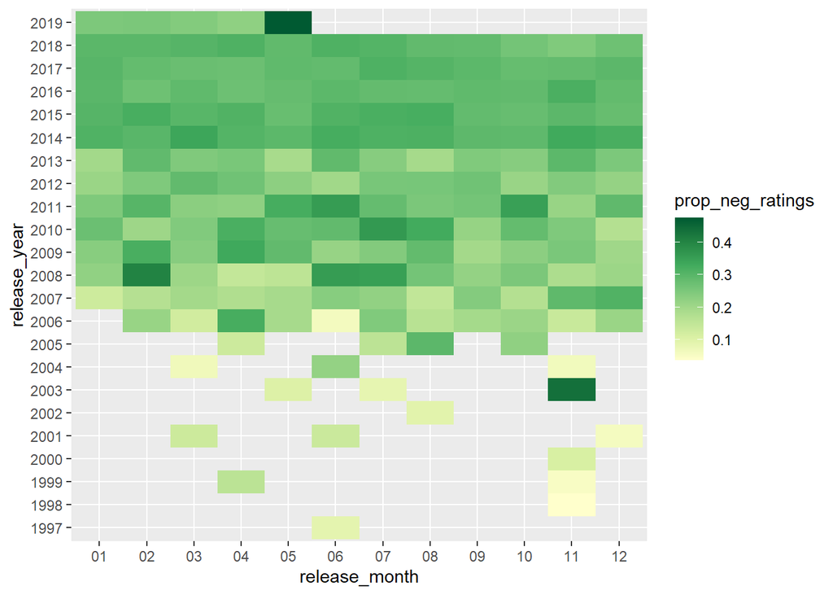

```r
ggplot(nrating_map,mapping = aes(x=release_month,y=release_year)) + geom_tile(mapping=aes(fill=prop_neg_ratings)) + scale_fill_distiller(palette = "YlGn", direction=2)
```

# **QUESTION 6: Is there a relationship between required age to play the game and the number of achievements?**

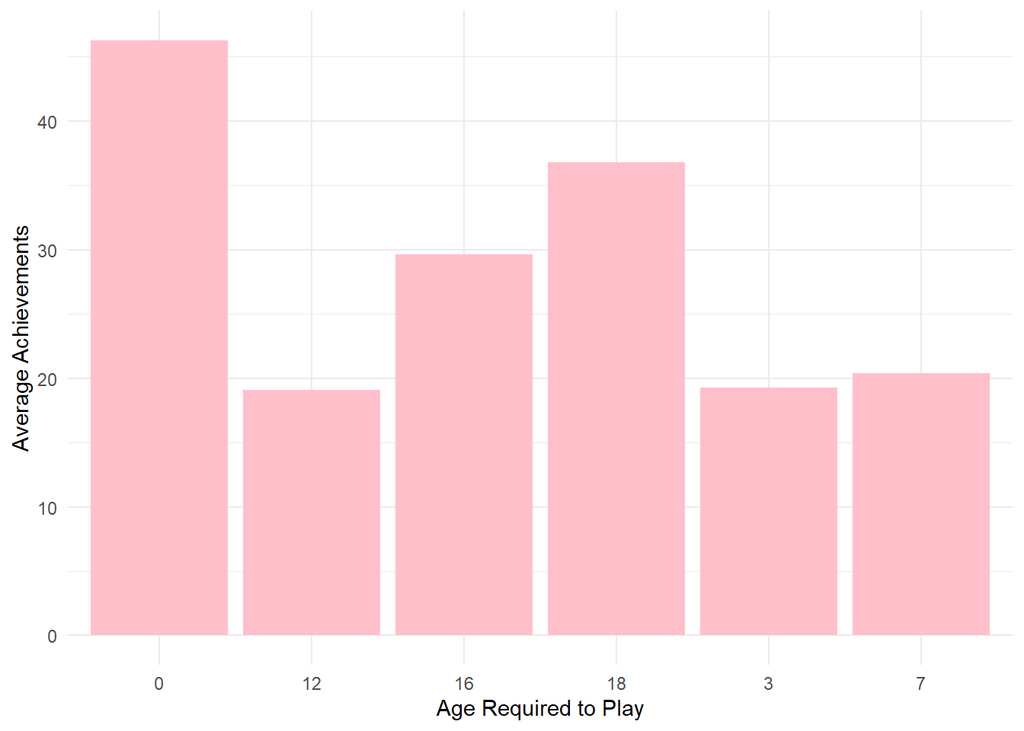

```r
co6 = steam_games_final %>%
  group_by(age) %>%
  summarise(average_achievements = mean(achievements))

ggplot(co6,aes(x=as.character(age),y=average_achievements)) +
  geom_bar(stat='identity',fill="pink") +
  xlab("Age Required to Play") + ylab("Average Achievements") +
  theme_minimal()
```

# **QUESTION 7: Are positive ratings higher for games that have longer average playtimes?**

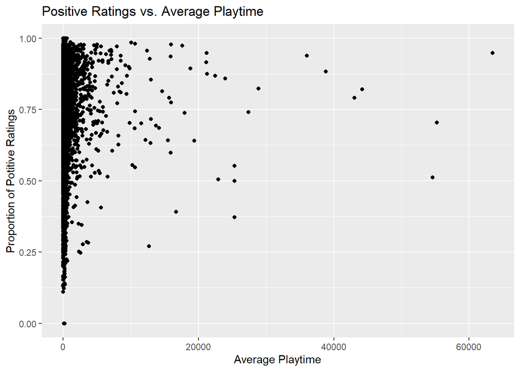

```r
steam_games_final=steam_games_final%>%
  mutate(pos_rate_prop=positive_ratings/(positive_ratings+negative_ratings))%>%
  mutate(neg_rate_prop=negative_ratings/(positive_ratings+negative_ratings))

playtimev.ratings= steam_games_final %>%
  select(pos_rate_prop, average_playtime,developer)%>%
  filter(average_playtime<75000)%>%
  filter(average_playtime>0)

ggplot(playtimev.ratings,aes(x=average_playtime,y=pos_rate_prop))+geom_point()+labs(x="Average Playtime", y="Proportion of Potitive Ratings", title="Positive Ratings vs. Average Playtime")
```

```r
##I filtered out all average playtimes that were 0 because games have to be played to be rated and greater than 75000 to reduce outliers.
```

# **FOLLOW UP QUESTION/CODE: How do the top ten developer games change in average playtime as their proportion of positive ratings increase?**

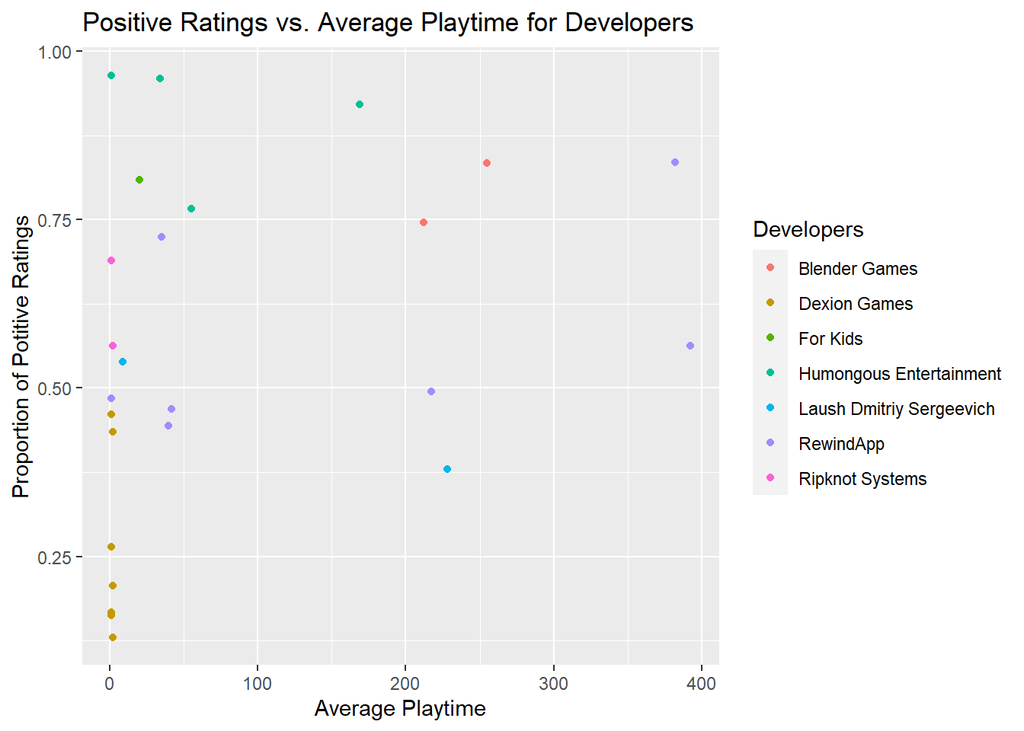

```r
develop= steam_games_final%>%
  select(positive_ratings, average_playtime, developer)%>%
  group_by(developer)%>%
  summarize(n=n())%>%
  arrange(desc(n))%>%
  head(10)
devplay=playtimev.ratings%>%
  semi_join(develop,by="developer")%>%
  filter(average_playtime<25000)

ggplot(devplay,aes(x=average_playtime,y=pos_rate_prop,color=developer)) +
  geom_point() +
  labs(x="Average Playtime", y="Proportion of Potitive Ratings", title="Positive Ratings vs. Average Playtime for Developers", color="Developers")
```

```r
##Top 10 developers are shown here, but only 7 appear because I filtered out any average playtimes that were 0. I also filtered out any average playtimes over 25000 hours to remove a singular outlier.
```

# **QUESTION 8: Is there a correlation between the number of owners and the price?**

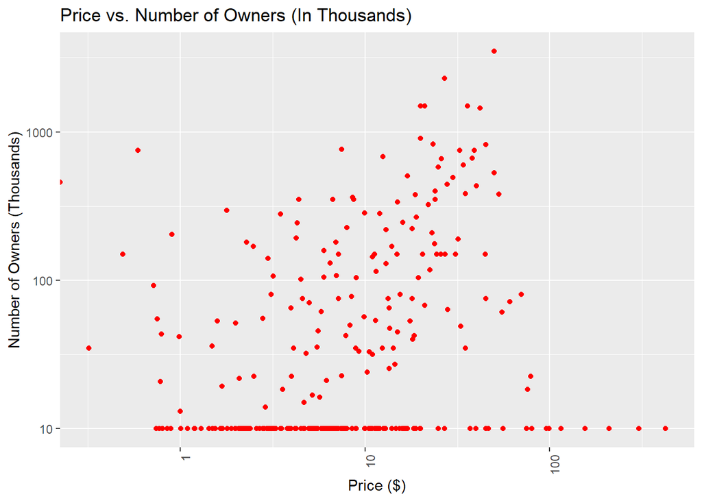

```r
find_mids = function(owners) {
  rowMid <- rowMeans(matrix(as.numeric(unlist(str_split(owners, pattern = "-"))),ncol = 2, byrow = T))
  return(rowMid / 1000)
}

ownersv.price= steam_games_final %>%
  select(price,owners) %>%
  filter(owners!=0) %>%
  group_by(price) %>%
  summarise(mean_owners = mean(find_mids(owners)))


ggplot(ownersv.price,aes(x=price, y=mean_owners)) +
  geom_point(color="red") +
  theme(axis.text.x = element_text(angle = 90, hjust = 1)) + labs(x="Price ($)", y="Number of Owners (Thousands)",title="Price vs. Number of Owners (In Thousands)") +
  scale_y_log10() +
  scale_x_log10()
```

# **QUESTION 9: Is there a relationship between the release date of a game and its age requirements?**

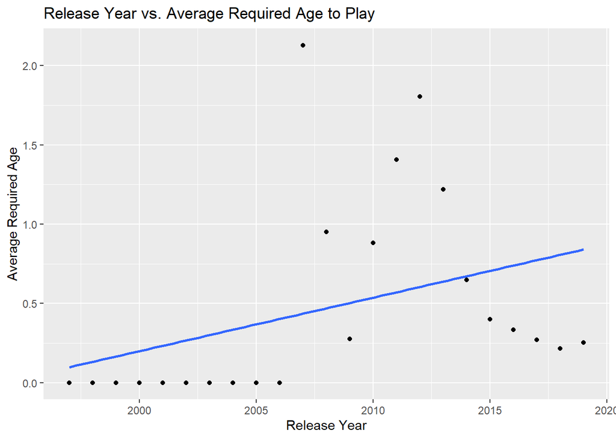

```r
steam_games_1 = steam_games_final %>%
  select(release_date,age) %>%
  mutate(release_year=str_replace_all(release_date,"-", "")) %>%
  mutate(release_year=substr(release_year,1,4)) %>%
  group_by(release_year) %>%
  summarize(mean_age=mean(age))

ggplot(steam_games_1, aes(x=as.numeric(release_year),y=mean_age)) +
  geom_point() + geom_smooth(method=lm,se=FALSE) + xlab("Release Year") + ylab("Average Required Age") + ggtitle("Release Year vs. Average Required Age to Play")
```

```r
# Note: many with 0 are unrated or unsupplied.
# group_by month and year
```

# **QUESTION 10: Is there a relationship between the number of platforms that the game can be played on and number of owners?**

```r
find_mids = function(owners) {
  rowMid <- rowMeans(matrix(as.numeric(unlist(str_split(owners, pattern = "-"))),ncol = 2, byrow = T))
  return(rowMid / 1000)
}

#owner_test = c("100-200", "200-400")
#test1 <- find_mids(owner_test)
#head(test1)

#test <- sapply(steam_games_final$owners, find_mids)
#head(test)

steam_games_4 = steam_games_final %>%
  mutate(mid_owner=find_mids(owners)) %>%
  group_by(num_platforms) %>%
  summarize(mean_mid_owner = mean(mid_owner))
steam_games_4
```

```
## # A tibble: 3 × 2
##   num_platforms mean_mid_owner
##           <dbl>          <dbl>
## 1             1           99.7
## 2             2          116.
## 3             3          296.
```

# **QUESTION 11: Is there a relationship between the amount of in game achievements and positive ratings?**

```r
q11 <- steam_games %>%
  select(achievements, positive_ratings, negative_ratings) %>%
  mutate(prop_pos = positive_ratings/(positive_ratings+negative_ratings)) %>%
  select(achievements, prop_pos) %>%
  filter(achievements<8000)

head(q11)
```

```
##   achievements  prop_pos
## 1            0 0.9738882
## 2            0 0.8397874
## 3            0 0.8956476
## 4            0 0.8266234
## 5            0 0.9479957
## 6            0 0.8012783
```

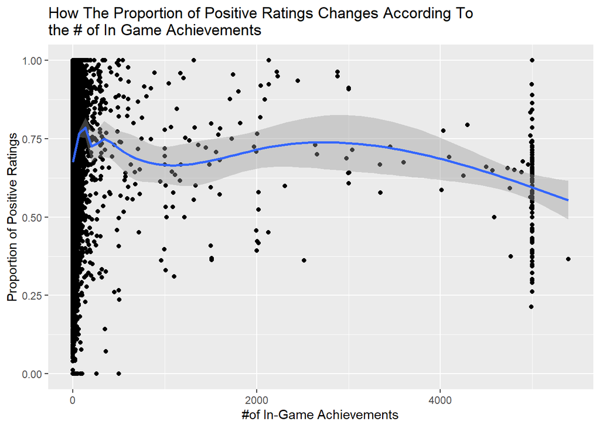

```r
q11_graph <- q11 %>%
  ggplot(aes(x=achievements, y=prop_pos)) +
  geom_point() +
  geom_smooth()+
  xlab("#of In-Game Achievements") + ylab("Proportion of Positive Ratings") +
  ggtitle("How The Proportion of Positive Ratings Changes According To \nthe # of In Game Achievements " )

q11_graph
```

# **QUESTION 12: Are games with more positive ratings priced higher than those with negative ratings?**

```r
q12 <- steam_games %>%
  select(price, positive_ratings, negative_ratings) %>%
  mutate(prop_pos = positive_ratings/(positive_ratings+negative_ratings)) %>%
  select(price, prop_pos)

head(arrange(q12, desc(prop_pos)))
```

```
##   price prop_pos
## 1  4.99        1
## 2 10.99        1
## 3  4.99        1
## 4  6.99        1
## 5  6.99        1
## 6  6.99        1
```

[figure not shown]

```r
q12_graph <- q12 %>%
  ggplot(aes(x=prop_pos, y=price)) +
  geom_point(aes(color = ifelse(prop_pos>0.5, 'salmon', 'turquoise'))) +
  scale_colour_manual(labels = c("More (-) Ratings", "More (+) Ratings"), values=c('turquoise', 'salmon')) +
  labs(color = "Ratings")+
  xlab("Proportion of Positive Ratings") + ylab("Price($)") +
  ggtitle("How Price Changes According to Rating")

q12_graph
```

# **Rubric**

| Requirement | Points |
| --- | --- |
| 1 Table or Figure for Each Initial Question | 4 Points |
| 4 Follow-Up Questions Proposed | 4 Points |
| 2 Tables and/or Figures for 2/4 Follow-Up Questions | 2 Points |
| Summary Paragraphs on Topic and Follow Instructions | 4 Points |
| Effective Communication of Results in Meeting | 3 Points |
| Written Summary Free of Errors | 1 Point |
| Followed RMarkdown Template | 1 Point |
| HTML Document Submitted | 1 Point |
| **Total** | **20 Points** |